# Homework Tidyverse

## 2_a:

- Repeat part 1 by using a `map_*()` function.

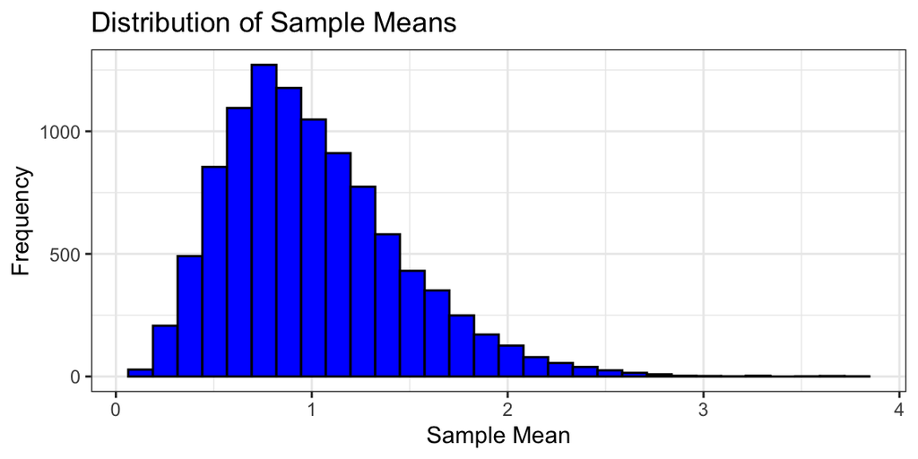

```r
#Calculate sample mean from each iteration in the rexp(rate=1)
means_map <- map_dbl(1:10000, \(i) mean(rexp(5, rate=1)))

#convert vector into data frame
df_map <- tibble(sample_mean = means_map)

#create histogram
ggplot(df_map, aes(x = sample_mean)) +
  geom_histogram(bins = 30, fill = "blue", color = "black") +
  labs(
    title = "Distribution of Sample Means",
    x = "Sample Mean",
    y = "Frequency"
  )
```

## 2_b:

- Repeat part 1 by using the `replicate()` function.

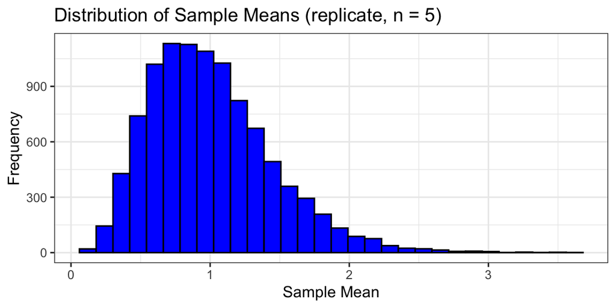

```r
#Repeat randomization and mean calculation 10000 times
means_rep <- replicate(10000, mean(rexp(5, rate=1)))

#Store results in tibble
df_rep <- tibble(sample_mean = means_rep)

#Plot distribution
ggplot(df_rep, aes(x = sample_mean)) +
  geom_histogram(bins = 30, fill = "blue", color = "black") +
  labs(
    title = "Distribution of Sample Means (replicate, n = 5)",
    x = "Sample Mean",
    y = "Frequency"
  )
```

## 2_c:

- Use a another for loop that will print out plots for sample sizes of 5, 10, and 20 observations (instead of just 5).

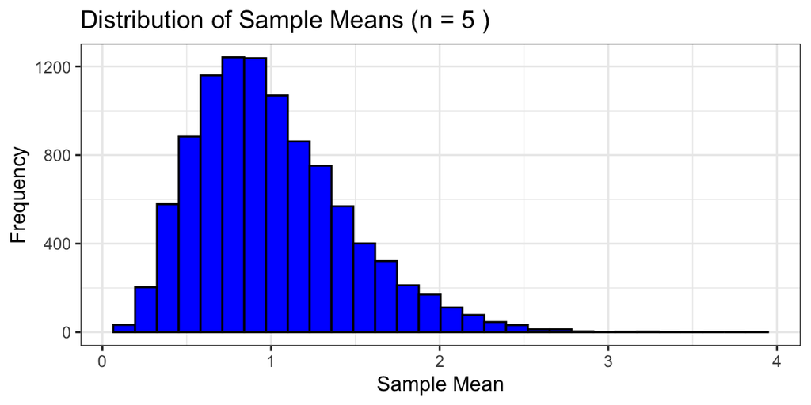

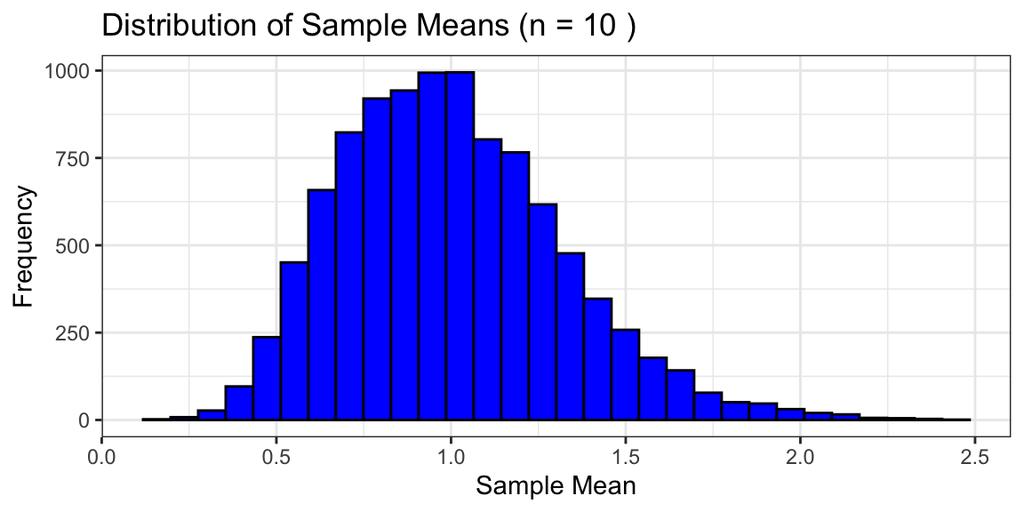

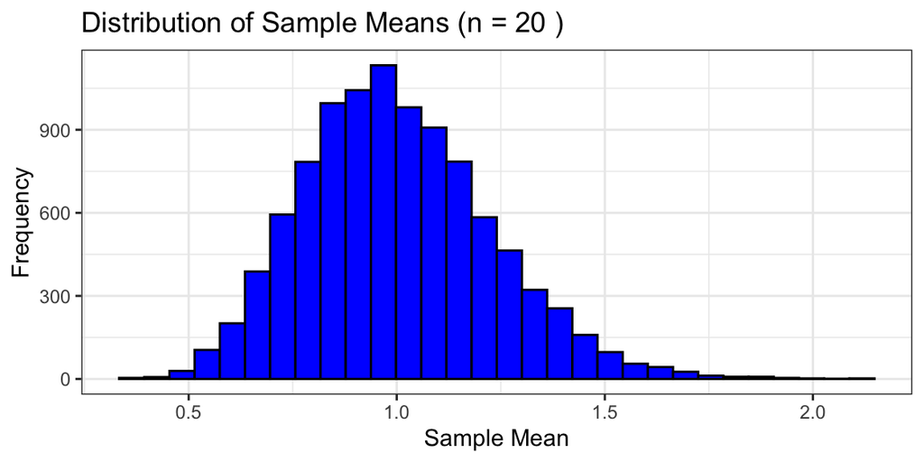

```r
# Define vector of sample sizes
sample_sizes <- c(5, 10, 20)

#For loop iterates through each sample
for (n in sample_sizes) {
  means <- vector("double", 10000)
  for (i in 1:10000) {
    means[[i]] <- mean(rexp(n, rate=1))
  }
  df_n <- tibble(sample_mean = means)
  p <- ggplot(df_n, aes(x = sample_mean)) +
    geom_histogram(bins = 30, fill = "blue", color = "black") +
    labs(
      title = paste("Distribution of Sample Means (n =", n, ")"),
      x = "Sample Mean",
      y = "Frequency"
    )

  print(p)
}
```

# Problem 3:

- Use and show R coding to calculate the “standard deviation” for each variable of the data table `mtcars` using the “Special For Loop Method”.

**Note:**

- There are two methods. Please see a quick explanation for both methods in below:
  - Method 1:

```r
  multi_return <- function() {
    my_list <- list("color" = "red", "size" = 20, "shape" = "round")
    return(my_list)
  }
```

```r
a <- multi_return()
a$color
```

```
[1] "red"
```

```r
a<- multi_return()
a$shape
```

```
[1] "round"
```

```r
a<- multi_return()
a$size
```

```
[1] 20
```

- Method 2. The “Special For Loop Method”

```r
output <- vector("double", ncol(df))  # 1. output (use appropriate data frame instead of df)
for (i in seq_along(df)) {            # 2. sequence
  output[[i]] <- median(df[[i]])      # 3. body
}
output
```

- **Solution:** coding to calculate the “standard deviation” for each variable

```r
# Get output vector with correct length and type
output <- vector("double", ncol(mtcars))
names(output) <- colnames(mtcars)

#Sequence mtcars columns
for(i in seq_along(mtcars)) {
  output[[i]] <- sd(mtcars[[i]])
}
output
```

```
        mpg         cyl        disp          hp        drat          wt
  6.0269481   1.7859216 123.9386938  68.5628685   0.5346787   0.9784574
       qsec          vs          am        gear        carb
  1.7869432   0.5040161   0.4989909   0.7378041   1.6152000
```

# Problem 4:

Generate a sequence of dates from **January 1, 2015** to **December 31, 2025**, spaced by every **two months**. Extract the **year**, **quarter**, and **ISO week number** for each date.

```r
#generate data sequence  from selected dates with two month spaces
dates_seq <- seq(from = ymd("2015-01-01"), to = ymd('2025-12-31'), by= "2 months")

#Extract year, quarter, and ISO week number into tibble
dates_tbl <- tibble(
  date     = dates_seq,
  year     = year(dates_seq),
  quarter  = quarter(dates_seq),
  iso_week = isoweek(dates_seq)
)

dates_tbl
```

```
# A tibble: 66 × 4
   date        year quarter iso_week
   <date>     <dbl>   <int>    <dbl>
 1 2015-01-01  2015       1        1
 2 2015-03-01  2015       1        9
 3 2015-05-01  2015       2       18
 4 2015-07-01  2015       3       27
 5 2015-09-01  2015       3       36
 6 2015-11-01  2015       4       44
 7 2016-01-01  2016       1       53
 8 2016-03-01  2016       1        9
 9 2016-05-01  2016       2       17
10 2016-07-01  2016       3       26
# ℹ 56 more rows
```

# Problem 5

Given the following dates, compute the difference in **months** and **weeks** between each consecutive pair.

```r
sample_dates <- c("2018-03-15", "2020-07-20", "2023-01-10", "2025-09-05")
```

```r
#input sample dates
sample_dates <- c("2018-03-15", "2020-07-20", "2023-01-10", "2025-09-05")

#turn string dates into objects
dates_parse <- ymd(sample_dates)

#define start dates and end dates
start_dates <- dates_parse[-length(dates_parse)]
end_dates <- dates_parse[-1]

#calculate difference in months and dates between pairs
date_diffs <- tibble(
  pair        = paste(start_dates, "to", end_dates),
  diff_months = (start_dates %--% end_dates) / months(1),
  diff_weeks  = (start_dates %--% end_dates) / weeks(1)
)

date_diffs
```

```
# A tibble: 3 × 3
  pair                     diff_months diff_weeks
  <chr>                          <dbl>      <dbl>
1 2018-03-15 to 2020-07-20        28.2       123.
2 2020-07-20 to 2023-01-10        29.7       129.
3 2023-01-10 to 2025-09-05        31.8       138.
```

# Problem 6

Given a list of mixed date formats, use `map()` and `possibly()` from `purrr` to safely convert them to **Date** format and extract the **month name**.

```r
date_strings <- list("2023-06-10", "2022/12/25", "15-Aug-2021", "InvalidDate")
```

```r
# Input list of date formats
date_strings <- list("2023-06-10", "2022/12/25", "15-Aug-2021", "InvalidDate")

#Wrap function in possibly() to handle errors
safe_parse <- possibly(
  function(x){
    as.Date(parse_date_time(x, orders = c("ymd", "dmy", "Ymd")))
  },
  otherwise = NA
)

#Apply safe parsing across all elements
parsed_dates <- map(date_strings, safe_parse)
#wrap month in possibly() to handle errors
safe_month <- possibly(
  function(d) {
    if (is.na(d)) return(NA_character_)
    as.character(month(d, label = TRUE, abbr = FALSE))
  },
  otherwise = NA_character_
)

#Apply safe month extraction across parsed dates
month_names <- map(parsed_dates, safe_month)

#Combine results
tibble(
  input      = unlist(date_strings),
  parsed     = do.call(c, parsed_dates),
  month_name = unlist(month_names)
)
```

```
# A tibble: 4 × 3
  input       parsed     month_name
  <chr>       <date>     <chr>
1 2023-06-10  2023-06-10 June
2 2022/12/25  2022-12-25 December
3 15-Aug-2021 2021-08-15 August
4 InvalidDate NA         <NA>
```